# Homework 5

Author

Sydney Ball

## Homework 5

The primary goal of homework 5 is to give you hands-on practice with a number of dplyr verbs we went over in Lecture 5.

Please consider going over the detailed slides presented during lecture 5 here: https://jmtfeliciano.github.io/DATA312Spring2025/Data312Spring2025_Lecture5

In lecture 6, we spent the entire class getting hands on experience with map making via Exercise6.rmd, so please revisit the filled in version of Exercise 6 we completed together: https://jmtfeliciano.github.io/DATA312Spring2025/Exercise6FilledIn

## Preliminaries

Run the scripts within the R chunk below before attempting the homework assignments:

```r
library(tidyverse)
library(tidygeocoder)
library(censusapi)
library(tigris)
```

## Problem 1 (0.5 pt)

Within the R chunk below, use one of the methods, functions, or tools we discussed from `tidygeocoder` to print the approximated longitude and latitude of this address: `4400 Massachusetts Ave NW, Washington, DC 20016`

```r
# Write your solution(s) below
addresses_df <- data.frame(address = c("4400 Massachusetts Ave NW, Washington, DC"))
geocode(addresses_df, address = address)
```

```
Passing 1 address to the Nominatim single address geocoder
```

```
Query completed in: 1 seconds
```

```
# A tibble: 1 × 3
  address                                     lat  long
  <chr>                                     <dbl> <dbl>
1 4400 Massachusetts Ave NW, Washington, DC  38.9 -77.1
```

## Problem 2 (1 pt)

The table you will need to complete and fill out completely (see prompt below):

[output not shown]

Using the R chunk below: use one of the methods, functions, or tools we discussed from `tidygeocoder` to print the approximated longitude and latitude of the addresses provided from the table above. **Make sure to fill in the table above after running your scripts**

```r
# Write your solution(s) below
czechia_address <- data.frame(address = c("Staroměstské nám. 1, Praha, Czechia"))
geocode(czechia_address, address = address)
```

```
Passing 1 address to the Nominatim single address geocoder
```

```
Query completed in: 1 seconds
```

```
# A tibble: 1 × 3
  address                               lat  long
  <chr>                               <dbl> <dbl>
1 Staroměstské nám. 1, Praha, Czechia  50.1  14.4
```

```r
cerritos_address <- data.frame(address = c("239 Los Cerritos Center, Cerritos, CA"))
geocode(cerritos_address, address = address)
```

```
Passing 1 address to the Nominatim single address geocoder
Query completed in: 1 seconds
```

```
# A tibble: 1 × 3
  address                                 lat  long
  <chr>                                 <dbl> <dbl>
1 239 Los Cerritos Center, Cerritos, CA  33.9 -118.
```

```r
pоссия_address <- data.frame(address = c("Москва, Россия, 109012"))
geocode(pоссия_address, address = address)
```

```
Passing 1 address to the Nominatim single address geocoder
Query completed in: 1 seconds
```

```
# A tibble: 1 × 3
  address                  lat  long
  <chr>                  <dbl> <dbl>
1 Москва, Россия, 109012  55.7  37.5
```

## Problem 3 (0.5 pt)

Within the R chunk below, use one of the methods, functions, or tools we discussed from `tidygeocoder` to print the county-level Census information for the following address: `4400 Massachusetts Ave NW, Washington, DC 20016`

```r
# Write your solution(s) below
dc_address <- data.frame(address = c("4400 Massachusetts Ave NW, Washington, DC 20016"))

dc_results <- geocode(dc_address, address = address, method = "census",
        full_results = TRUE, api_options = list(census_return_type = 'geographies'))
```

```
Passing 1 address to the US Census single address geocoder
```

```
Query completed in: 0.4 seconds
```

```r
# Script you need to run to see county information
dc_results$geographies.Counties
```

```
[[1]]
  GEOID     CENTLAT AREAWATER STATE             BASENAME            OID LSADC
1 11001 +38.9047586  18709787    11 District of Columbia 27590331264532    00
  FUNCSTAT    INTPTLAT                 NAME OBJECTID      CENTLON COUNTYCC
1        F +38.9042474 District of Columbia     2587 -077.0162860       H6
  COUNTYNS  AREALAND     INTPTLON MTFCC COUNTY
1 01702382 158316180 -077.0165167 G4020    001
```

```r
# Script you need to run to see county information
dc_results$`geographies.Census Tracts`
```

```
[[1]]
        GEOID     CENTLAT AREAWATER STATE BASENAME              OID LSADC
1 11001000903 +38.9376821         0    11     9.03 2079015504267572    CT
  FUNCSTAT    INTPTLAT              NAME OBJECTID  TRACT      CENTLON AREALAND
1        S +38.9376821 Census Tract 9.03    16300 000903 -077.0933310   928101
      INTPTLON MTFCC COUNTY
1 -077.0933310 G5020    001
```

## Problem 4 (1 pt)

The table you will need to complete and fill out completely (see prompt below):

Using the R chunk below: use one of the methods, functions, or tools we discussed from `tidygeocoder` to print the approximated longitude and latitude of the addresses provided from the table above. **Make sure to fill in the table above after running your scripts.** Note: You will have to run three separate `geocode()` since `geocode()` usually do not allow multiple addresses when `method = "census"`

| Address | Five digit County GEOID/FIPS |
| --- | --- |
| `21 West Side Dr, Rehoboth Beach, DE 19971` | 10005 |
| `36 Fire Island Blvd, Fire Island Pines, NY 11782` | 36103 |
| `539 Commercial St, Provincetown, MA 02657` | 25001 |

**Hint you may not be given in a midterm:** it might be a good idea to run three separate geocode() and each one is saved into the R environment with a unique name. You may also add additional R chunks if desired.

```r
# Write your solution(s) below
beach_address <- data.frame(address = c("21 West Side Dr, Rehoboth Beach, DE 19971"))

beach_results <- geocode(beach_address, address = address, method = "census",
        full_results = TRUE, api_options = list(census_return_type = 'geographies'))
```

```
Passing 1 address to the US Census single address geocoder
```

```
Query completed in: 0.3 seconds
```

```r
beach_results$geographies.Counties
```

```
[[1]]
  GEOID     CENTLAT AREAWATER STATE BASENAME            OID LSADC FUNCSTAT
1 10005 +38.6832032 674129050    10   Sussex 27590337189172    06        A
     INTPTLAT          NAME OBJECTID      CENTLON COUNTYCC COUNTYNS   AREALAND
1 +38.6732275 Sussex County      256 -075.3395931       H1 00217269 2424590444
      INTPTLON MTFCC COUNTY
1 -075.3370237 G4020    005
```

```r
#----------------------------------------------

fireisland_address <- data.frame(address = c("36 Fire Island Blvd, Fire Island Pines, NY 11782"))

fireisland_results <- geocode(fireisland_address, address = address, method = "census",
        full_results = TRUE, api_options = list(census_return_type = 'geographies'))
```

```
Passing 1 address to the US Census single address geocoder
Query completed in: 0.3 seconds
```

```r
fireisland_results$geographies.Counties
```

```
[[1]]
  GEOID     CENTLAT  AREAWATER STATE BASENAME            OID LSADC FUNCSTAT
1 36103 +40.9409757 3787388318    36  Suffolk 27590498683575    06        A
     INTPTLAT           NAME OBJECTID      CENTLON COUNTYCC COUNTYNS   AREALAND
1 +40.9435540 Suffolk County     2213 -072.6868445       H1 00974149 2359306967
      INTPTLON MTFCC COUNTY
1 -072.6922183 G4020    103
```

```r
#----------------------------------------------

provincetown_address <- data.frame(address = c("539 Commercial St, Provincetown, MA 02657"))

provinceton_results <- geocode(provincetown_address, address = address, method = "census",
        full_results = TRUE, api_options = list(census_return_type = 'geographies'))
```

```
Passing 1 address to the US Census single address geocoder
```

```
Query completed in: 0.2 seconds
```

```r
provinceton_results$geographies.Counties
```

```
[[1]]
  GEOID     CENTLAT  AREAWATER STATE   BASENAME            OID LSADC FUNCSTAT
1 25001 +41.7732559 2360362410    25 Barnstable 27590203617241    06        A
     INTPTLAT              NAME OBJECTID      CENTLON COUNTYCC COUNTYNS
1 +41.7061233 Barnstable County     2486 -070.2384278       H1 00606927
    AREALAND     INTPTLON MTFCC COUNTY
1 1020973603 -070.1648227 G4020    001
```

## Problem 5 (1 pt)

Within the R chunk below, use one of the methods, functions, or tools we discussed from `tidygeocoder` to print the estimated/approximated address from the following coordinates: (a) longitude of -77.08755 and (b) latitude of 38.93584.

```r
# Write your solution(s) below
reverse_geo(lat = "-77.08755", long = "38.93584")
```

```
Passing 1 coordinate to the Nominatim single coordinate geocoder
```

```
Query completed in: 1 seconds
```

```
# A tibble: 1 × 3
    lat  long address
  <dbl> <dbl> <chr>
1 -77.1  38.9 <NA>
```

## Problem 6 Background Information

In class, we briefly discussed the idea of **`left_join(table1, table2)`**, where `table1` represents our primary table while `table2` is the table we want to get supplemental data from. You may think of left_join() as allowing you to supplement data from `table2` into `table1`. For this to work, `table1` and `table2` need to have a share a common variable (e.g, both tables have a common variable named `social_security_number`).

**`table3 <- left_join(table1, table2)`** represents the same idea but instead of just visualizing or printing the merged data, the assignment operator simply saves the resulting table into the R environment.

## Problem 6 (1 pt)

Before proceeding, run the next two R chunks and make sure to pause to read the printed data to understand the structure of the data/

**R chunk for students_data:**

```r
# run this script
students_data <- read_csv("https://raw.githubusercontent.com/jmtfeliciano/teachingdata/refs/heads/main/students_data.csv")
head(students_data)
```

```
# A tibble: 5 × 3
  student_id name    major
       <dbl> <chr>   <chr>
1          1 Alice   Math
2          2 Bob     Physics
3          3 Charlie Biology
4          4 David   Chemistry
5          5 Eva     Statistics
```

**R chunk for** grades_data**:**

```r
# run this script
grades_data <- read_csv("https://raw.githubusercontent.com/jmtfeliciano/teachingdata/refs/heads/main/grades_data.csv")
head(grades_data)
```

```
# A tibble: 4 × 2
  student_id   gpa
       <dbl> <dbl>
1          1  3.31
2          2  2.97
3          3  3.63
4          4  4
```

Using the R chunk below, use `left_join()` to combine the two tables from above so you pull the gpa data into the primary students_data table. Save the resulting R object into your R environment as `combined_data`. Afterwards, use head() to verify that `combined_data` worked as intended.

```r
# Write your solution(s) below
comined_data <- left_join(students_data, grades_data)
head(comined_data)
```

```
# A tibble: 5 × 4
  student_id name    major        gpa
       <dbl> <chr>   <chr>      <dbl>
1          1 Alice   Math        3.31
2          2 Bob     Physics     2.97
3          3 Charlie Biology     3.63
4          4 David   Chemistry   4
5          5 Eva     Statistics NA
```

## Problem 7 Background Information

Before proceeding, run the next two R chunks and make sure to pause to read the printed data to understand the structure of the data.

a. R chunk for demographic_data

```r
# run this script
demographic_data <- read_csv("https://raw.githubusercontent.com/jmtfeliciano/teachingdata/refs/heads/main/demo_data.csv")
head(demographic_data)
```

```
# A tibble: 4 × 2
  social_security_number full_name
  <chr>                  <chr>
1 111-22-3333            Kendrick Lamar
2 444-55-6666            Aubrey Drake Graham
3 777-88-9999            Solana Imani Rowe
4 123-45-6789            Serena Williams
```

b. R chunk for birth_city_data

```r
# run this script
birth_city_data <- read_csv("https://raw.githubusercontent.com/jmtfeliciano/teachingdata/refs/heads/main/birth_city_data.csv")
head(birth_city_data)
```

```
# A tibble: 4 × 2
  ssn         birth_city
  <chr>       <chr>
1 111-22-3333 Compton, CA, USA
2 444-55-6666 Toronto, ON, CAN
3 777-88-9999 St. Louis, MO, USA
4 123-45-6789 Saginaw, MI, USA
```

Now, run the following script in Console and pay attention to the error printed for: `left_join(demographic_data, birth_city_data)`

After reading the error message, look at the tables printed above again to see variable names of each columns. Are the column 1s in each data frame share the same data but different names? If yes, how would you fix this?

## Problem 7 (1 pt)

```r
# Code you need to correct below

demographic_data <- read_csv("https://raw.githubusercontent.com/jmtfeliciano/teachingdata/refs/heads/main/demo_data.csv")
birth_city_data <- read_csv("https://raw.githubusercontent.com/jmtfeliciano/teachingdata/refs/heads/main/birth_city_data.csv")
#rename the colum of SSN so that both names match
new_demographic_data <- demographic_data |>
  rename(ssn = social_security_number)

head(new_demographic_data)
```

```
# A tibble: 4 × 2
  ssn         full_name
  <chr>       <chr>
1 111-22-3333 Kendrick Lamar
2 444-55-6666 Aubrey Drake Graham
3 777-88-9999 Solana Imani Rowe
4 123-45-6789 Serena Williams
```

```r
#use "ssn" as join key
combined_data <- left_join(new_demographic_data, birth_city_data)
head(combined_data)
```

```
# A tibble: 4 × 3
  ssn         full_name           birth_city
  <chr>       <chr>               <chr>
1 111-22-3333 Kendrick Lamar      Compton, CA, USA
2 444-55-6666 Aubrey Drake Graham Toronto, ON, CAN
3 777-88-9999 Solana Imani Rowe   St. Louis, MO, USA
4 123-45-6789 Serena Williams     Saginaw, MI, USA
```

## Problem 8 (2 pt)

Using the `tigris` package and the techniques taught in lecture and lab exercises, create a map using data from `breast_cancer_state_mortality_2023.csv` to show the breast cancer mortality rate for states across the US in 2023. The variable you need is `deaths_per_100000`.

You may add additional R chunks below if desired.

```r
# Place your code below
nationwide_shapefile <- states(year = 2021) |>
  filter(!NAME %in% c("American Samoa", "Commonwealth of the Northern Mariana Islands", "Commonwealth of the Northern Mariana Islands", "Guam", "United States Virgin Islands")) |>
  shift_geometry()
new_breast_cancer_state_mortality_2023 <- read.csv("~/Desktop/new_breast_cancer_state_mortality_2023.csv") |>
  mutate(GEOID = as.numeric(GEOID))

head(new_breast_cancer_state_mortality_2023)
```

```
                 State GEOID deaths_per_100000
1 District of Columbia    11              24.0
2          Mississippi    28              23.4
3             Oklahoma    40              22.4
4            Louisiana    22              22.1
5             Delaware    10              22.0
6               Nevada    32              21.7
```

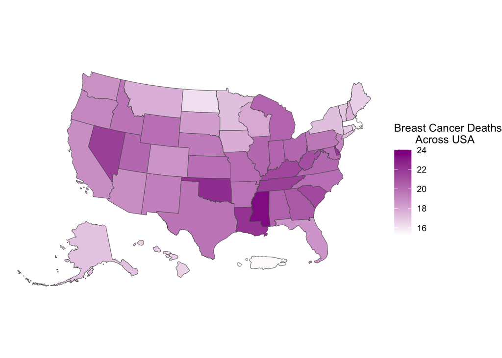

```r
nationwide_shapefile <- states(year = 2023) |>
  mutate(GEOID = as.numeric(GEOID)) |>
  filter(!NAME %in% c("American Samoa", "Commonwealth of the Northern Mariana Islands", "Commonwealth of the Northern Mariana Islands", "Guam", "United States Virgin Islands")) |>
  shift_geometry()
nationwide_breastcancer <- left_join(nationwide_shapefile, new_breast_cancer_state_mortality_2023)
ggplot(nationwide_breastcancer, aes(fill = deaths_per_100000)) +
  geom_sf() +
  theme_void() +
  scale_fill_gradient(low="white", high="magenta4", labels = scales::comma) +
  labs(fill='Breast Cancer Deaths\
       Across USA')
```

## Problem 9 (2 pt)

Using the `tigris` package and the techniques taught in lecture and lab exercises, create a map using data from `presidential_election1964.csv` to plot or indicate which states won by Barry Goldwater vs Lyndon B. Johnson in the 1964 presidential election. `Victor` is the variable you’d want to plot here. **Note:** the map of states across the US hasn’t really changed significantly since 1959 when Hawaii became the 50th state. I am mentioning this because `states(year = 1964)` will not work since it does not exist in the API where `tigris` pulls the data from, so please use any recent year for the state map or shapefile in this homework.

You may add additional R chunks below if desired.

```r
# Place your code below
presidential_election1964 <- read.csv("~/Desktop/presidential_election1964.csv") |>
  mutate(GEOID = as.numeric(GEOID)) |>
  mutate(presidentialDummy = ifelse(Victor == "Johnson", 1, 0))

head(presidential_election1964)
```

```
  GEOID  StateName    Victor presidentialDummy
1     1    Alabama Goldwater                 0
2     2     Alaska   Johnson                 1
3     4    Arizona Goldwater                 0
4     5   Arkansas   Johnson                 1
5     6 California   Johnson                 1
6     8   Colorado   Johnson                 1
```

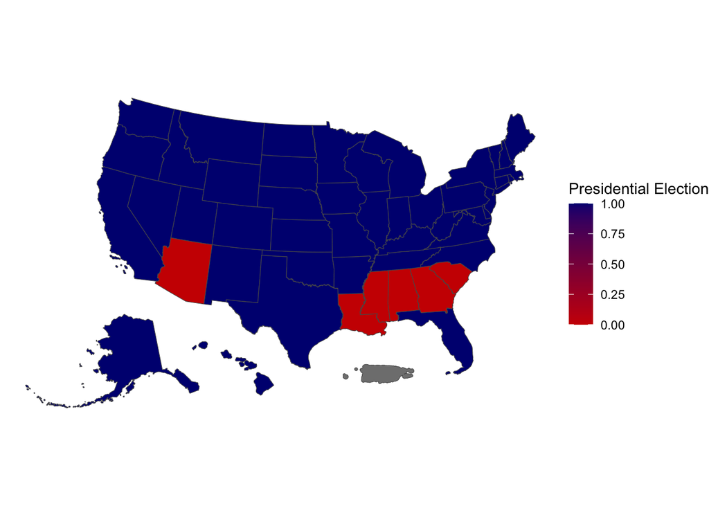

```r
presidential_nationwide_shapefile <- states(year = 2023) |>
  mutate(GEOID = as.numeric(GEOID)) |>
  filter(!NAME %in% c("American Samoa", "Commonwealth of the Northern Mariana Islands", "Commonwealth of the Northern Mariana Islands", "Guam", "United States Virgin Islands")) |>
  shift_geometry()

nationwide_presidential_race <- left_join(presidential_nationwide_shapefile, presidential_election1964)
ggplot(nationwide_presidential_race, aes(fill = presidentialDummy)) +
  geom_sf() +
  theme_void() +
  scale_fill_gradient(low="red3", high="navy", labels = scales::comma) +
  labs(fill='Presidential Election')
```